# Assignment 8: Applied Linear Regression

Leandro Ledesma

2024-11-04

# Learning Objectives

1. Learn to conduct multiple regression analysis in R.
2. Learn to assess regression assumptions in R.
3. Learn to interpret and report multiple regression analysis. Dataset Description: Use the dataset “College Success” from the online JASP Data Repository (https://johnnydoorn.github.io/DataLibraryBookdown/myChapters/chapter_4.html). This data set provides high school grades, SAT scores, and Grade Point Average of 224 university students. Variables:
- id - Participant ID
- gpa - Grade Point Average (GPA) after three semester in college
- hsm - Average high-school grade in mathematics
- hss - Average high-school grade in science
- hse - Average high-school grade in English
- satm - SAT score for mathematics
- satv - SAT score for verbal knowledge
- sex - Gender (labels not available)

Notes for Analysis: In this assignment, you will run a series of models to predict gpa in college, using:

- hsm, hss, and hsm as covariates
- satm and satv as predictors
- the interaction between satm and satv

### Data Desctiptives

```r
# Load the data
data <- read.delim("https://raw.githubusercontent.com/jasp-stats/jasp-data-library/main/College%20Success/College%20Success.csv", sep = "," )

# glimpse it
glimpse(data)
```

```
Rows: 224
Columns: 8
$ id   <int> 1, 2, 3, 4, 5, 6, 7, 8, 9, 10, 11, 12, 13, 14, 15, 16, 17, 18, 19…
$ gpa  <dbl> 3.32, 2.26, 2.35, 2.08, 3.38, 3.29, 3.21, 2.00, 3.18, 2.34, 3.08,…
$ hsm  <int> 10, 6, 8, 9, 8, 10, 8, 3, 9, 7, 9, 5, 6, 10, 8, 10, 10, 9, 9, 9, …
$ hss  <int> 10, 8, 6, 10, 9, 8, 8, 7, 10, 7, 10, 9, 8, 9, 9, 10, 10, 9, 6, 10…
$ hse  <int> 10, 5, 8, 7, 8, 8, 7, 6, 8, 6, 6, 7, 8, 9, 6, 9, 9, 8, 5, 9, 8, 7…
$ satm <int> 670, 700, 640, 670, 540, 760, 600, 460, 670, 570, 491, 600, 510, …
$ satv <int> 600, 640, 530, 600, 580, 630, 400, 530, 450, 480, 488, 600, 530, …
$ sex  <int> 1, 1, 1, 1, 1, 1, 1, 1, 1, 1, 1, 1, 1, 1, 1, 1, 1, 1, 1, 1, 1, 1,…
```

## Section 1. Conduct a Regression Analysis.

### Compute and report correlations among all variables in the model.

- The variables sex and id were removed from correlation matrix
- The correlation table below shows that all variables are correlation to each other. Ignoring the outcome (gpa), we can see that the predictors and covariates are moderately and weakly correlated with each other. The first pattern we can notice is that high school performance tends to correlate pretty well with each other (ex: hsm and hss, hss and hse, hse and hsm). However, the correlations between high school grades and performance on the SAT is much weaker in comparison with the exception for math.

```r
# Remove the sex variable
data2 <- select(data,-c(sex, id))

# run a correlation matrix
round(cor(data2),2) %>%
  kbl(caption = "Correlation Matrix of Predictors, Covariates, and the Outcome") %>%
  kable_paper("hover", full_width = F)
```

Correlation Matrix of Predictors, Covariates, and the Outcome

|  | gpa | hsm | hss | hse | satm | satv |
| --- | --- | --- | --- | --- | --- | --- |
| gpa | 1.00 | 0.44 | 0.33 | 0.29 | 0.25 | 0.11 |
| hsm | 0.44 | 1.00 | 0.58 | 0.45 | 0.45 | 0.22 |
| hss | 0.33 | 0.58 | 1.00 | 0.58 | 0.24 | 0.26 |
| hse | 0.29 | 0.45 | 0.58 | 1.00 | 0.11 | 0.24 |
| satm | 0.25 | 0.45 | 0.24 | 0.11 | 1.00 | 0.46 |
| satv | 0.11 | 0.22 | 0.26 | 0.24 | 0.46 | 1.00 |

## Name and report findings for all 5 regression assumptions discussed in class, using figures when appropriate.

We will first start by fitting the full model, which includes the predictors and covariates of interest in the prediction of gpa scores.

- **Assumption 1**: Multivariate normality. To test this, we need to create a model and obtain the error terms. These are the values that represent the difference of the observed scores of Y from the predicted scores. We can then run several tests to identify if the distribution of the errors are normally distributed. The issue is these tests are very sensitive to the sample size, and large sample sizes will cause the tests to be biased. A better approach is to produce a Q-Q plot of the residuals.
- From the plot below, I would say that we could potentially call it normal. Clearly the dots are not on the lines as we would expect, however, I think that this would be passible in an analysis, it’s just that the left side of the tail is a little heavy.

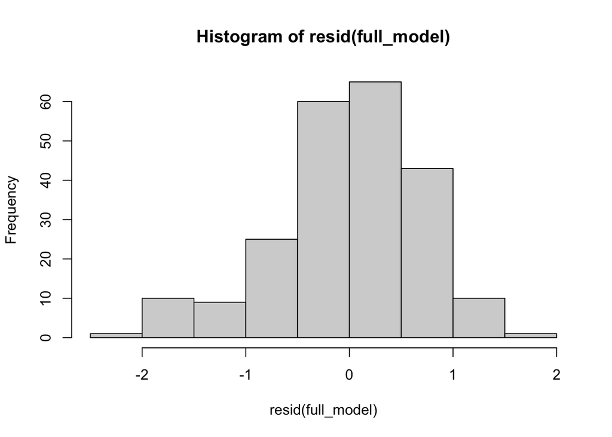

```r
# Create the full model
full_model <-  lm(gpa ~ hsm + hss + hse + satm * satv, data)

# Plot a histogram
hist(resid(full_model))
```

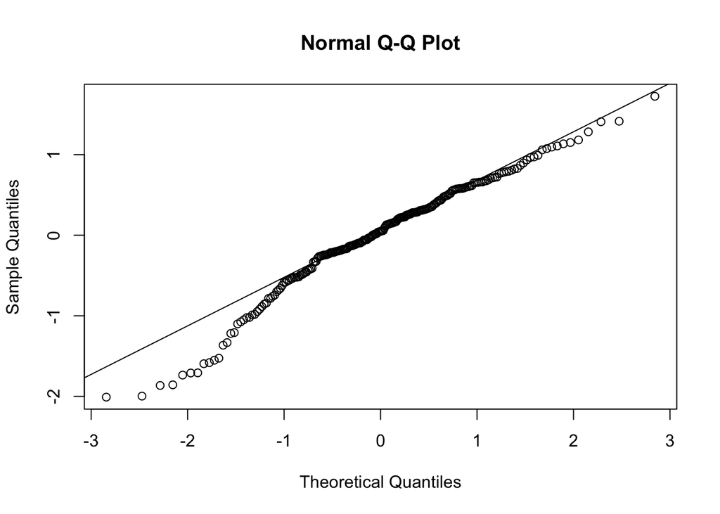

```r
# Check for the normality of residuals assumption
qqnorm(resid(full_model))
qqline(resid(full_model))
```

- **Assumption 2**: Linearity. We can plot the relationship between the predictors/covariates and the outcome (gpa). We can do this easily using ggplot and some for loops.
- From the plots below, it is a little difficult to tell since the high school measures are restricted to integers ranging from 1-10, which then creates a weird pattern when plotted. The plots that may cause concern are hss and gpa, and hse and gpa. The lines in these plots look slightly curved and not exactly like straight lines. If some of the observations are outliers, then potentially these lines could look like straight lines after the outliers are removed.

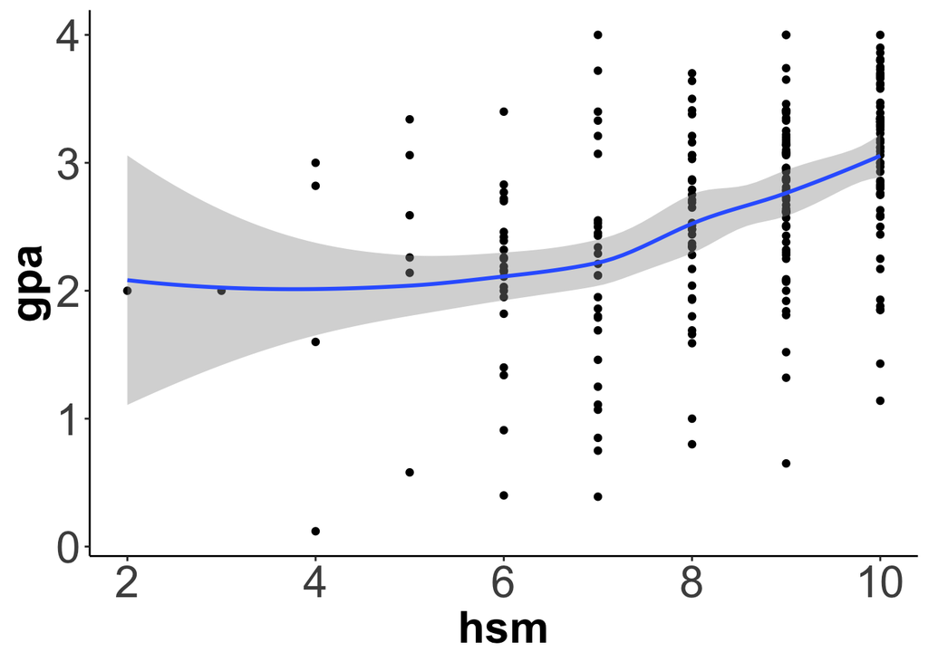

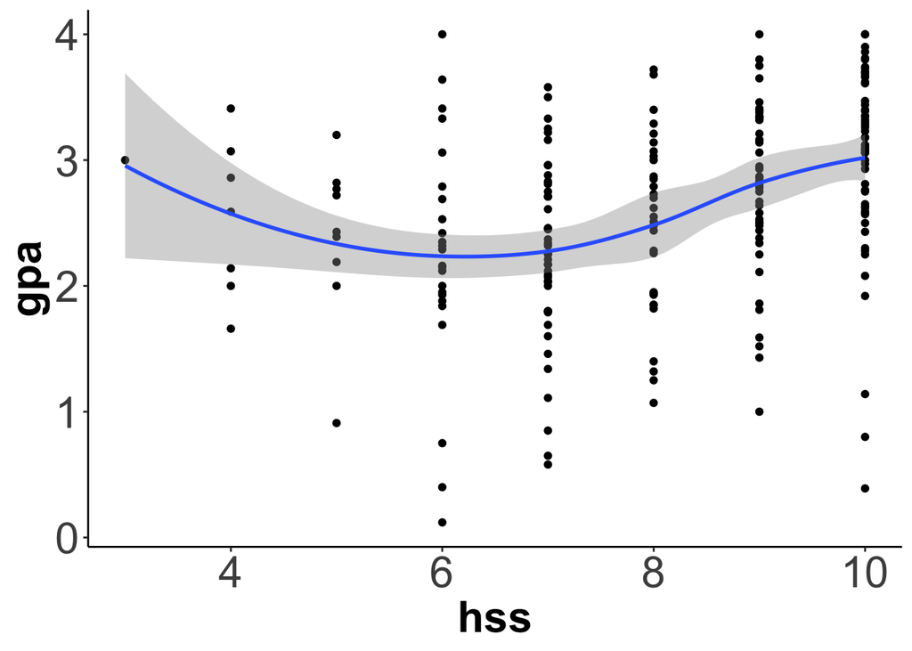

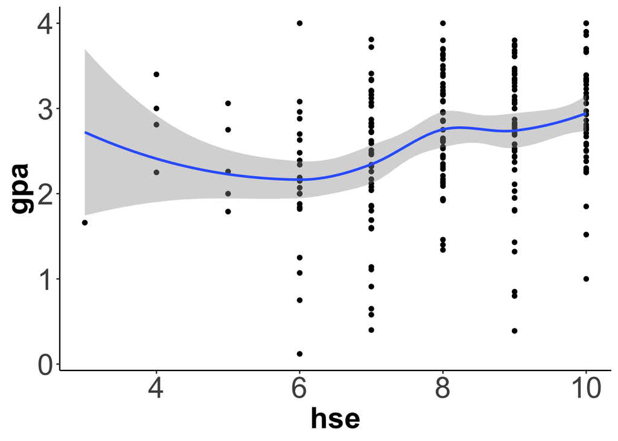

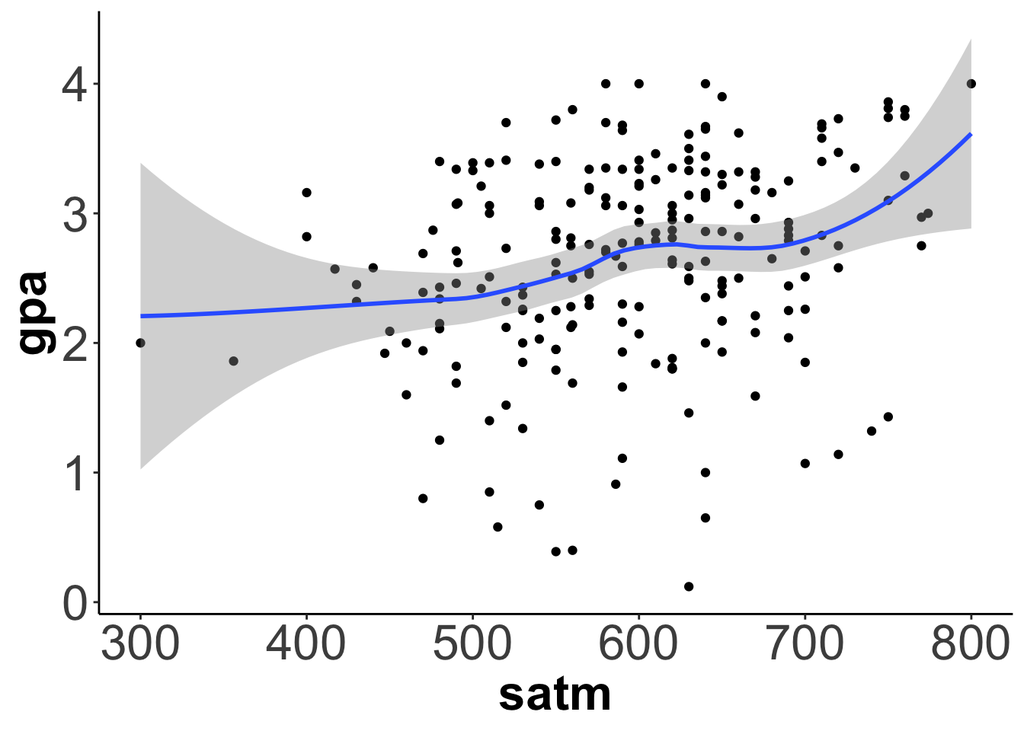

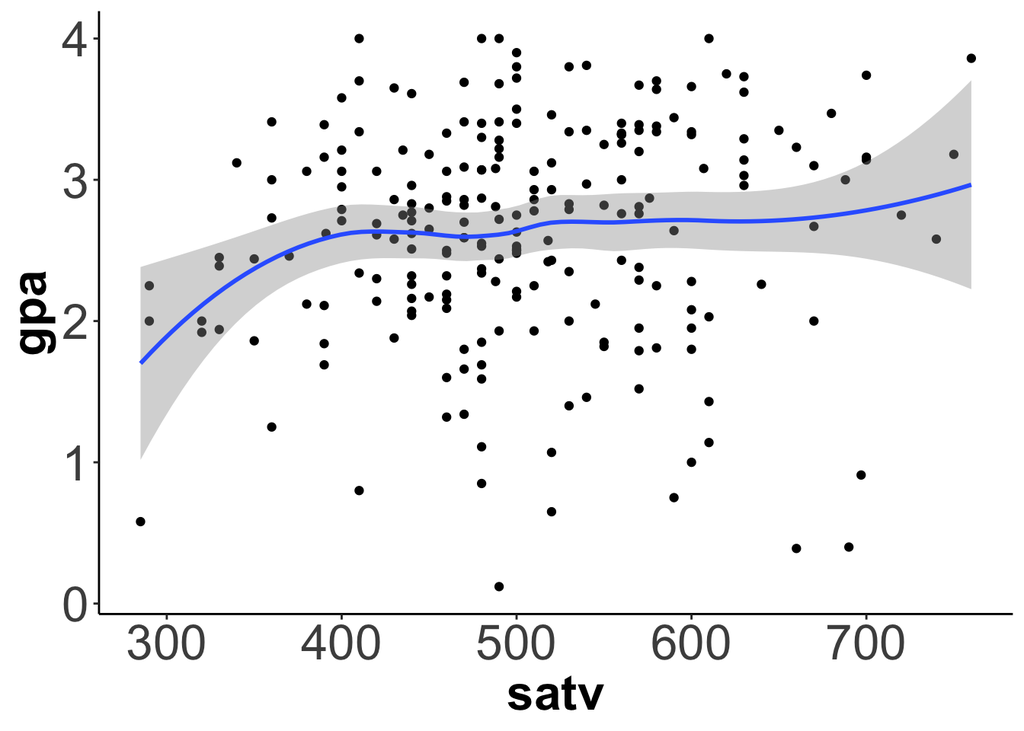

```r
# Create vectors for the predictors and for the outcome
predictors <- data %>% select(hsm:satv)
outcome <- select(data, gpa)

# Create a for loop to plot the graphs
for(ii in 1:length(predictors)) {

  # extract the current predictor
  currentPred <- predictors[ii]

  # Bind it to the outcome
  currentData <- cbind(currentPred, outcome)

  # rename the variables
  orgNames <- names(currentData)
  names(currentData) <- c("x", "y")

  # Create the plot
  currentPlot <- currentData %>%
    ggplot(aes(x=x, y=y)) +
    geom_point() +
    geom_smooth() +
    theme_classic() +
    labs(
       x = orgNames[1],
       y = orgNames[2]) +
    theme(plot.title = element_text(size = 14,
                                  hjust = 0.5),
        axis.title = element_text(size = 24,
                                  face = "bold"),
        axis.text = element_text(size = 24),
        plot.caption = element_text(size = 13,
                                    hjust = 0))


  plot(currentPlot)
}
```

- **Assumption 3:** The assumption of independent observations. This means that all observations are not coming from the same participants (not repeated measures) and that observations are in no way nested into some groupings that have been failed to be accounted for. We can use the table function to identify that each observation corresponds to a unique ID. We will also assume that there is no nesting taking place!

```r
table(data$id)
```

```
  1   2   3   4   5   6   7   8   9  10  11  12  13  14  15  16  17  18  19  20
  1   1   1   1   1   1   1   1   1   1   1   1   1   1   1   1   1   1   1   1
 21  22  23  24  25  26  27  28  29  30  31  32  33  34  35  36  37  38  39  40
  1   1   1   1   1   1   1   1   1   1   1   1   1   1   1   1   1   1   1   1
 41  42  43  44  45  46  47  48  49  50  51  52  53  54  55  56  57  58  59  60
  1   1   1   1   1   1   1   1   1   1   1   1   1   1   1   1   1   1   1   1
 61  62  63  64  65  66  67  68  69  70  71  72  73  74  75  76  77  78  79  80
  1   1   1   1   1   1   1   1   1   1   1   1   1   1   1   1   1   1   1   1
 81  82  83  84  85  86  87  88  89  90  91  92  93  94  95  96  97  98  99 100
  1   1   1   1   1   1   1   1   1   1   1   1   1   1   1   1   1   1   1   1
101 102 103 104 105 106 107 108 109 110 111 112 113 114 115 116 117 118 119 120
  1   1   1   1   1   1   1   1   1   1   1   1   1   1   1   1   1   1   1   1
121 122 123 124 125 126 127 128 129 130 131 132 133 134 135 136 137 138 139 140
  1   1   1   1   1   1   1   1   1   1   1   1   1   1   1   1   1   1   1   1
141 142 143 144 145 146 147 148 149 150 151 152 153 154 155 156 157 158 159 160
  1   1   1   1   1   1   1   1   1   1   1   1   1   1   1   1   1   1   1   1
161 162 163 164 165 166 167 168 169 170 171 172 173 174 175 176 177 178 179 180
  1   1   1   1   1   1   1   1   1   1   1   1   1   1   1   1   1   1   1   1
181 182 183 184 185 186 187 188 189 190 191 192 193 194 195 196 197 198 199 200
  1   1   1   1   1   1   1   1   1   1   1   1   1   1   1   1   1   1   1   1
201 202 203 204 205 206 207 208 209 210 211 212 213 214 215 216 217 218 219 220
  1   1   1   1   1   1   1   1   1   1   1   1   1   1   1   1   1   1   1   1
221 222 223 224
  1   1   1   1
```

**Assumption 4**: The assumption of homoscedasticity. This assumption looks at the distribution of errors across the levels of fitted values. We want the errors to be evenly distributed in the plot below, which indicates that there is good variance in the errors across the levels of the fitted values. This looks okay with the except of some errors on the lower end of the fitted values.

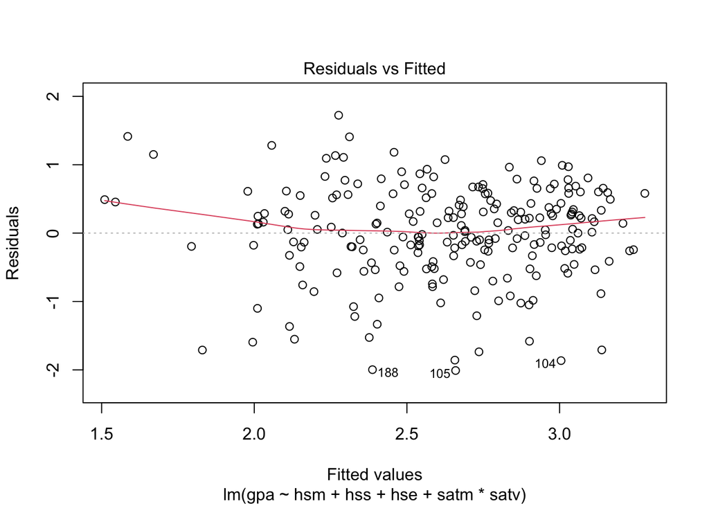

```r
plot(full_model, which = 1)
```

**Assumption 5**: No Multicollinearity. We can check this before running the model by looking at the correlations between predictors and covariates. Additionally we can use the variance inflation factor after running the model to see if there is no multicollinearity. We can use the vif() function from the car package to do this.

We see that the vif values are exceedling high! This is not surprising since the interaction is literally the product of two predictors, thus we would expect it to correlate highly with them. In this example the assumption of multicollinearity is violated because the VIF values are larger than 5. However, we could also center our variables, rerun the analysis and then look at VIF. In this case we see that all values are smaller than 5 and that this assumption (when using this centered model), is not violated.

```r
# Obtain the vif values
round(vif(full_model),2)
```

```
      hsm       hss       hse      satm      satv satm:satv
     1.89      1.90      1.64     21.93     36.43     81.26
```

```r
# Create centered predictors
data <- data %>%
  mutate(hsm.c = hsm - mean(hsm),
         hss.c = hss - mean(hss),
         hse.c = hse - mean(hse),
         satm.c = satm - mean(satm),
         satv.c = satv - mean(satv))

# Rerun the model
full_model_centered <- lm(gpa ~ hsm.c + hss.c + hse.c + satm.c * satv.c, data)

round(vif(full_model_centered),2)
```

```
        hsm.c         hss.c         hse.c        satm.c        satv.c
         1.89          1.90          1.64          1.61          1.37
satm.c:satv.c
         1.03
```

## Use the following rules for removing outliers and variables:

1. Remove outlier values for gpa, hsm, hss, hse, satm, and satv that are beyond ±4.0 standard deviations from the mean. To remove these values, change the value to NA in the dataset.
- Did you need to remove any values? If so, which ones?
- No values were removed since no one’s standardized scores were less than - 4 or greater than 4 standard deviations away from the mean for each respective predictor and the outcome.

```r
# We can standardized all of our numeric variables using the scale() function
data$gpa.s <- c(scale(data$gpa))
data$hsm.s <- c(scale(data$hsm))
data$hss.s <- c(scale(data$hss))
data$hse.s <- c(scale(data$hse))
data$satm.s <- c(scale(data$satm))
data$satv.s <- c(scale(data$satv))

# Select only the standardized variables
standardized.var  <- data %>% select(gpa.s:satv.s)

# Identify if any outliers exist
sapply(standardized.var, function(x) min(x))
```

```
    gpa.s     hsm.s     hss.s     hse.s    satm.s    satv.s
-3.227149 -3.857501 -2.994292 -3.378101 -3.417602 -2.370673
```

```r
sapply(standardized.var, function(x) max(x))
```

```
   gpa.s    hsm.s    hss.s    hse.s   satm.s   satv.s
1.751072 1.024308 1.124173 1.264197 2.369339 2.758337
```

2. Keep all predictors in models. Remove covariates from the final model that have an initial VIF of greater than 5.0.
- Did you remove any variables from the model? Which ones?
- I centered my predictors and covariates, which resulted in VIF scores all smaller than 5. Thus, all variables will remain in the model.

## Run a set of models and compare models to one another appropriately

1. Covariate only model
2. Covariate + main effects
3. Covariate + main effects + interaction
- After comparing models, it seems like the best model is the one with covariates only. Introducing additional predictors to the model with covariates does not statistically reduce the residual sum of squares.

```r
# Covariate only model
cov_model <- lm(gpa ~ hsm.c + hss.c + hse.c, data)

# Covariate and main effects model
cov_main_model <- lm(gpa ~ hsm.c + hss.c + hse.c + satm.c + satv.c, data)

# Covariate, main effects, and interaction model
full_model_centered <- lm(gpa ~ hsm.c + hss.c + hse.c + satm.c * satv.c, data)

# model comparison
anova(cov_model, cov_main_model, full_model_centered)
```

```
Analysis of Variance Table

Model 1: gpa ~ hsm.c + hss.c + hse.c
Model 2: gpa ~ hsm.c + hss.c + hse.c + satm.c + satv.c
Model 3: gpa ~ hsm.c + hss.c + hse.c + satm.c * satv.c
  Res.Df    RSS Df Sum of Sq      F Pr(>F)
1    220 107.75
2    218 106.82  2   0.93131 0.9503 0.3882
3    217 106.33  1   0.49230 1.0047 0.3173
```

```r
# summary
summary(cov_model)
```

```
Call:
lm(formula = gpa ~ hsm.c + hss.c + hse.c, data = data)

Residuals:
     Min       1Q   Median       3Q      Max
-2.12892 -0.34072  0.07568  0.47445  1.75365

Coefficients:
            Estimate Std. Error t value Pr(>|t|)
(Intercept)  2.63522    0.04676  56.356  < 2e-16 ***
hsm.c        0.16857    0.03549   4.749 3.68e-06 ***
hss.c        0.03432    0.03756   0.914    0.362
hse.c        0.04510    0.03870   1.166    0.245
---
Signif. codes:  0 '***' 0.001 '**' 0.01 '*' 0.05 '.' 0.1 ' ' 1

Residual standard error: 0.6998 on 220 degrees of freedom
Multiple R-squared:  0.2046,    Adjusted R-squared:  0.1937
F-statistic: 18.86 on 3 and 220 DF,  p-value: 6.359e-11
```

## Visualize results using a ggplot figure

You can create any figure, as long as it clearly shows the found relationships among predictor(s) and outcome.

- We will be ploting the slopes and intercepts of the covariate model. We will obtain the slopes from each covariate (while controlling for the effects of the other covariates) and introduce that slope with the y-intercept into the plot using the geom_abline() function. The covariates below are centered, thus the y-intercept represents the point in the line where x =0, which is the average of the covariates.

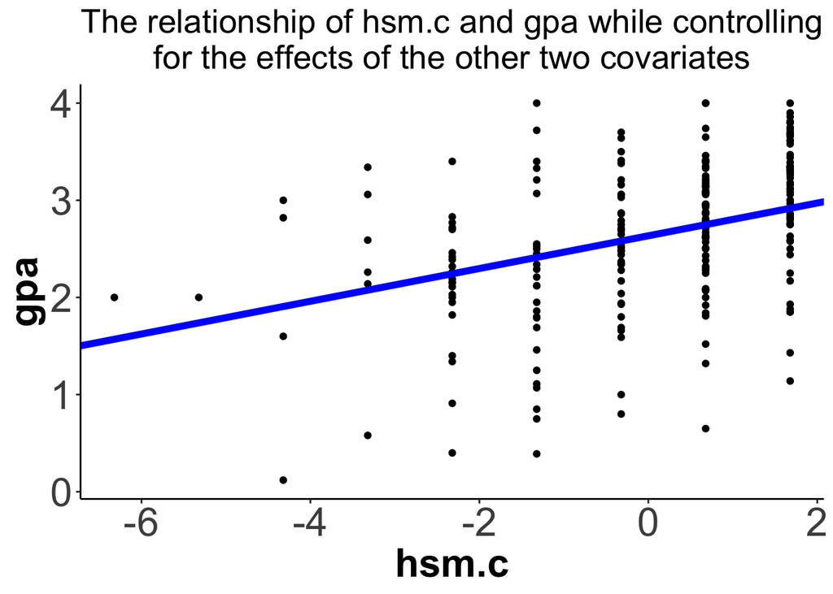

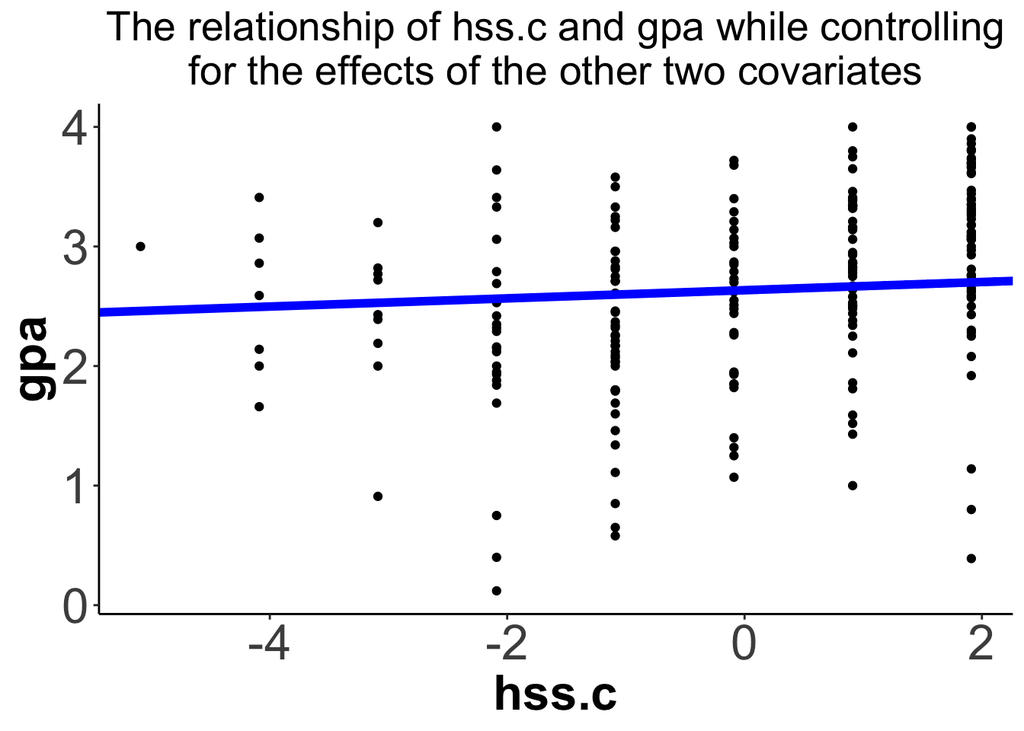

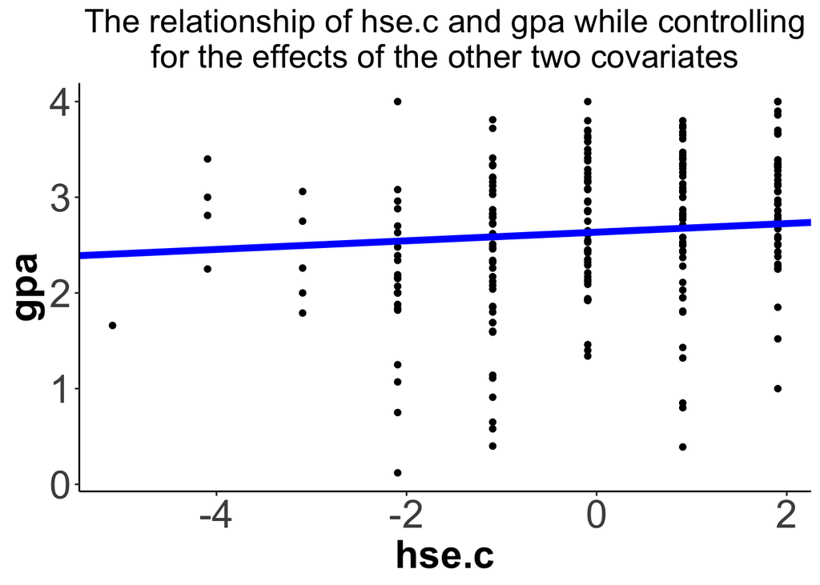

```r
# Obtain the variables of only the covariates
covariate_df <- data %>%
  select(gpa, hsm.c:hse.c)

for(ii in 1:(length(covariate_df)-1)) {

  # Obtain the intercept of the covariate model
  intercept <- coef(cov_model)[1]

  # Obtain the slope of one of the covariates
  slope <- coef(cov_model)[ii + 1]

  # Obtain the name of the current covariate
  currentCov <- names(coef(cov_model)[ii + 1])

  # Extract the varibles of interest
  cov_df <- covariate_df[, c(currentCov, "gpa")]

  # Rename the variables
  names(cov_df) <- c("x", "y")

  # Create a title
  title = paste0("The relationship of ",currentCov," and gpa while controlling\nfor the effects of the other two covariates")

  # Create a graph
  currentPlot <- cov_df %>%
    ggplot(aes(x= x, y = y)) +
    geom_point() +
    geom_abline(intercept = intercept, slope = slope, color = "blue", size = 2) +
    theme_classic() +
    labs(title = title,
       x = currentCov,
       y = "gpa") +
    theme(plot.title = element_text(size = 20,
                                  hjust = 0.5),
        axis.title = element_text(size = 24,
                                  face = "bold"),
        axis.text = element_text(size = 24),
        plot.caption = element_text(size = 13,
                                    hjust = 0))

  plot(currentPlot)

}
```